# Data Analysis

```python
from IPython.display import HTML

HTML('''<script>
code_show=true;
function code_toggle() {
 if (code_show){
 $('div.input').hide();
 } else {
 $('div.input').show();
 }
 code_show = !code_show
}
$( document ).ready(code_toggle);
</script>
<form action="javascript:code_toggle()"><input type="submit" value="Click here to toggle on/off the raw code."></form>''')
```

### 1) Importing and Processing the Data

Our dataset, collected via FRED website, is a time series data tracking the Georgia Housing index from 2000 to 2019.

The **dependent variable** of the study is the Housing Index, where we investigate what factors may play a bigger role in affecting the change of the index.

The **independent of the study** includes:

1. New Private Housing Units - The number of new private housing established  
   (measures the average price changes for homes that are sold or refinanced)
2. Median Household Income - The median household income in Georgia
3. Unemployment Rate - The unemployment rate in Georgia
4. All employee, Social Assistance - The number of employee hired in Social Assistance sector **in thousand of person**  
   (As an indicator to measure the growth of the Social Assistance sector in GA)
5. All employee, Education, Health Service - The number of employee hired in Education and Health sector **in thousand of person**  
   (As an indicator to measure the growth of the Education, Health Service sector in GA)

| Variables | Description |
| --- | --- |
| New Private Housing Units | The number of new private housing established |
| Median Household Income | The median household income in Georgia |
| Unemployment Rate | The unemployment rate in Georgia |
| All employee, Social Assistance | The number of employee hired in Social Assistance sector **in thousand of person** |
| All employee, Education, Health Service | The number of employee hired in Education and Health sector **in thousand of person** |

```python
# import the necessary package
import numpy as np
import pandas as pd
from matplotlib import style
import matplotlib.pyplot as plt
import seaborn as sns
import statsmodels.api as sm
import statsmodels.formula.api as smf
import scipy.stats as stats
from stargazer.stargazer import Stargazer
from IPython.core.display import HTML

# import data
house = pd.read_csv('GA house_new.csv')

house.head(5).round(3)
```

|  | DATE | Housing Index | New Private Housing Units | Unemployment rate | All employee, Social Assistance | All Employee, Education, Health Service | Median Household Income |
| --- | --- | --- | --- | --- | --- | --- | --- |
| 0 | 2000-01-01 | 229.98 | 7993.215 | 3.633 | 309.833 | 345.900 | 41901 |
| 1 | 2000-04-01 | 233.73 | 7696.030 | 3.700 | 311.733 | 348.767 | 41901 |
| 2 | 2000-07-01 | 237.51 | 7486.818 | 3.600 | 312.800 | 352.267 | 41901 |
| 3 | 2000-10-01 | 241.40 | 7551.964 | 3.400 | 315.433 | 354.533 | 41901 |
| 4 | 2001-01-01 | 248.19 | 7833.710 | 3.567 | 315.867 | 358.000 | 42576 |

#### Desprictive Analysis

After having an clear idea of what the dataset is about. Next, it is necessary to have a look at a statistical summary of our dataset.

```python
house.describe().round(3)
```

|  | Housing Index | New Private Housing Units | Unemployment rate | All employee, Social Assistance | All Employee, Education, Health Service | Median Household Income |
| --- | --- | --- | --- | --- | --- | --- |
| count | 80.000 | 80.000 | 80.000 | 80.000 | 80.000 | 80.000 |
| mean | 295.154 | 4924.321 | 6.082 | 408.727 | 474.074 | 47690.150 |
| std | 37.565 | 2654.502 | 2.280 | 60.762 | 76.497 | 5021.495 |
| min | 229.980 | 1222.641 | 3.133 | 309.833 | 345.900 | 40984.000 |
| 25% | 265.507 | 2802.340 | 4.475 | 359.158 | 411.492 | 43239.750 |
| 50% | 290.180 | 4246.093 | 5.150 | 403.367 | 469.367 | 46609.500 |
| 75% | 319.662 | 7700.416 | 7.708 | 456.242 | 533.050 | 49858.250 |
| max | 389.630 | 9752.292 | 10.600 | 527.133 | 621.567 | 57985.000 |

The average value for the Georgia Housing Index was estimated at 295.154 with a standard deviation of 37.565. The lowest index was 229.98 which was recorded in 2000Q1 and was ascribed to the early 2000 recession along with the multiple downfalls of tech giants.The maximum was 389.63, a record high, in 2019Q4 which was considered one of the most prosperour period in 2010S.

### Data Cleaning

```python
house.info()
```

```
<class 'pandas.core.frame.DataFrame'>
RangeIndex: 80 entries, 0 to 79
Data columns (total 7 columns):
 #   Column                                   Non-Null Count  Dtype
---  ------                                   --------------  -----
 0   DATE                                     80 non-null     object
 1   Housing Index                            80 non-null     float64
 2   New Private Housing Units                80 non-null     float64
 3   Unemployment rate                        80 non-null     float64
 4   All employee, Social Assistance          80 non-null     float64
 5   All Employee, Education, Health Service  80 non-null     float64
 6   Median Household Income                  80 non-null     int64
dtypes: float64(5), int64(1), object(1)
memory usage: 4.5+ KB
```

Although the data is pre-cleaned before importing into Jupyter Notebook, we still want to elicit more insight from the original dataset. As a result, we decisde to add addition features to the dataset and extrace more relevent information from the columns. Here are what we came up:

Additional Features:

- `monthYea` : extract only the month and the year in the date object to make the graph tidier

```python
house.insert(7, "monthYear", len(house), True)
house['monthYear']  = house['DATE'].apply(lambda x: (str(x)[:7]) if x == x else np.nan)
house.head()
```

|  | DATE | Housing Index | New Private Housing Units | Unemployment rate | All employee, Social Assistance | All Employee, Education, Health Service | Median Household Income | monthYear |
| --- | --- | --- | --- | --- | --- | --- | --- | --- |
| 0 | 2000-01-01 | 229.98 | 7993.215447 | 3.633333 | 309.833333 | 345.900000 | 41901 | 2000-01 |
| 1 | 2000-04-01 | 233.73 | 7696.030050 | 3.700000 | 311.733333 | 348.766667 | 41901 | 2000-04 |
| 2 | 2000-07-01 | 237.51 | 7486.817740 | 3.600000 | 312.800000 | 352.266667 | 41901 | 2000-07 |
| 3 | 2000-10-01 | 241.40 | 7551.963652 | 3.400000 | 315.433333 | 354.533333 | 41901 | 2000-10 |
| 4 | 2001-01-01 | 248.19 | 7833.710288 | 3.566667 | 315.866667 | 358.000000 | 42576 | 2001-01 |

```python
house['monthYear'] = pd.to_datetime(house['monthYear'])
house.info()
house.head(5).round(3)
```

```
<class 'pandas.core.frame.DataFrame'>
RangeIndex: 80 entries, 0 to 79
Data columns (total 8 columns):
 #   Column                                   Non-Null Count  Dtype
---  ------                                   --------------  -----
 0   DATE                                     80 non-null     object
 1   Housing Index                            80 non-null     float64
 2   New Private Housing Units                80 non-null     float64
 3   Unemployment rate                        80 non-null     float64
 4   All employee, Social Assistance          80 non-null     float64
 5   All Employee, Education, Health Service  80 non-null     float64
 6   Median Household Income                  80 non-null     int64
 7   monthYear                                80 non-null     datetime64[ns]
dtypes: datetime64[ns](1), float64(5), int64(1), object(1)
memory usage: 5.1+ KB
```

|  | DATE | Housing Index | New Private Housing Units | Unemployment rate | All employee, Social Assistance | All Employee, Education, Health Service | Median Household Income | monthYear |
| --- | --- | --- | --- | --- | --- | --- | --- | --- |
| 0 | 2000-01-01 | 229.98 | 7993.215 | 3.633 | 309.833 | 345.900 | 41901 | 2000-01-01 |
| 1 | 2000-04-01 | 233.73 | 7696.030 | 3.700 | 311.733 | 348.767 | 41901 | 2000-04-01 |
| 2 | 2000-07-01 | 237.51 | 7486.818 | 3.600 | 312.800 | 352.267 | 41901 | 2000-07-01 |
| 3 | 2000-10-01 | 241.40 | 7551.964 | 3.400 | 315.433 | 354.533 | 41901 | 2000-10-01 |
| 4 | 2001-01-01 | 248.19 | 7833.710 | 3.567 | 315.867 | 358.000 | 42576 | 2001-01-01 |

We also create a new dataframe `houseDiff` to calculate the difference between each rows. We can later utilize this dataframe to conduct regression analysis of change of our independent variables

```python
# create a copy the original dataframe
houseDiff = house.copy()
# write a for-loop to calculate the difference and add it to the new dataframe
for i in range(0, len(house)):
    if i == 0:
        houseDiff["Housing Index"][i] = 0
        houseDiff["New Private Housing Units"][i] = 0
        houseDiff["Unemployment rate"][i] = 0
        houseDiff["All employee, Social Assistance "][i] = 0
        houseDiff["All Employee, Education, Health Service"][i] = 0
        houseDiff["Median Household Income"][i] = 0
    else:
        houseDiff["Housing Index"][i] = houseDiff["Housing Index"][i] - house["Housing Index"][i - 1]
        houseDiff["New Private Housing Units"][i] = houseDiff["New Private Housing Units"][i] - house["New Private Housing Units"][i - 1]
        houseDiff["Unemployment rate"][i] = houseDiff["Unemployment rate"][i] - house["Unemployment rate"][i - 1]
        houseDiff["All employee, Social Assistance "][i] = houseDiff["All employee, Social Assistance "][i] - house["All employee, Social Assistance "][i - 1]
        houseDiff["All Employee, Education, Health Service"][i] = houseDiff["All Employee, Education, Health Service"][i] - house["All Employee, Education, Health Service"][i - 1]
        houseDiff["Median Household Income"][i] = houseDiff["Median Household Income"][i] - house["Median Household Income"][i - 1]
houseDiff.head().round(3)
```

[output not shown]

|  | DATE | Housing Index | New Private Housing Units | Unemployment rate | All employee, Social Assistance | All Employee, Education, Health Service | Median Household Income | monthYear |
| --- | --- | --- | --- | --- | --- | --- | --- | --- |
| 0 | 2000-01-01 | 0.00 | 0.000 | 0.000 | 0.000 | 0.000 | 0 | 2000-01-01 |
| 1 | 2000-04-01 | 3.75 | -297.185 | 0.067 | 1.900 | 2.867 | 0 | 2000-04-01 |
| 2 | 2000-07-01 | 3.78 | -209.212 | -0.100 | 1.067 | 3.500 | 0 | 2000-07-01 |
| 3 | 2000-10-01 | 3.89 | 65.146 | -0.200 | 2.633 | 2.267 | 0 | 2000-10-01 |
| 4 | 2001-01-01 | 6.79 | 281.747 | 0.167 | 0.433 | 3.467 | 675 | 2001-01-01 |

### Data Visualization

Before conducting any regression analysis, let's first inpect the data set to a further extent! With the housing index as the dependent variable, we have to find some linear relationships with our regressors by implementing scatter plots. These variables are further used for building our regression models. For statistical visualizations, we used seaborn and matplotlib as the main workhorse.

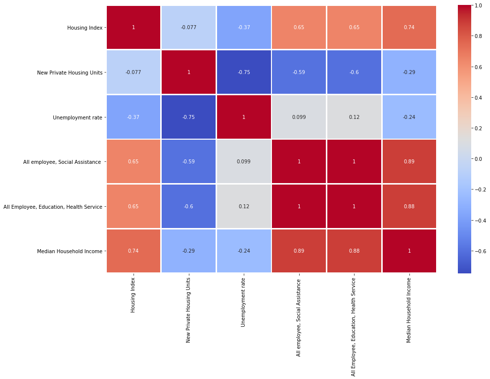

```python
fig, ax = plt.subplots()
fig.set_size_inches(15, 10)
sns.heatmap(house.corr(),cmap='coolwarm',ax=ax,annot=True,linewidths=2)
```

**Housing Index vs. Median Household Income**

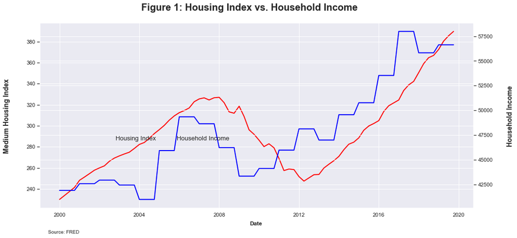

```python
sns.set_theme(style="darkgrid")
fig, ax = plt.subplots(figsize = (16, 7))
ax.plot(house.monthYear, house['Housing Index'], linewidth = 2, c = 'red')

fig.text(0.06, 0.5, "Medium Housing Index", va = 'center', weight = 'bold', fontsize = 14, rotation = 'vertical')
fig.text(0.50, 0.06, 'Date', va = 'center', weight = 'bold', fontsize = 12)
fig.suptitle("Figure 1: Housing Index vs. Household Income", weight = 'bold', fontsize = 20, y = 0.96)
fig.text(0.14, 0.02, 'Source: FRED', fontsize = 10, weight = 'normal')

fig.text(0.26, 0.40, "Housing Index",  weight = 'normal', fontsize = 13)
fig.text(0.37, 0.40, "Household Income",  weight = 'normal', fontsize = 13)

ax2= ax.twinx()
ax2.plot(house.monthYear, house['Median Household Income'], linewidth = 2, c = 'blue')
fig.text(0.96, 0.5, "Household Income", va = 'center', weight = 'bold', fontsize = 14, rotation = 'vertical')
```

Since personal assetthe is a major factor that influence us whether to own a house or not, We suspect that there might be a strong correlation between the median household income and the housing index.

The graph shows that there is indeed a similar positive trend between these two variables. One interesting fact that is worth notice is that before the intersection in 2010, there is a period of time where the housing index continues to rise depite the lowlevel household income, suggesting that people might purchase houses in a irrational level that exceeds their budget during that time.

**Housing Index vs. Unemployment**

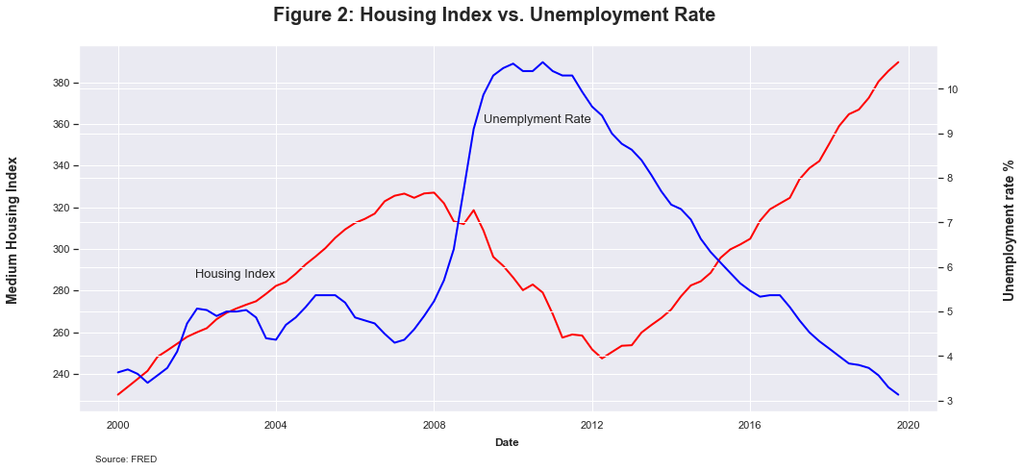

```python
sns.set_theme(style="darkgrid")
fig, ax = plt.subplots(figsize = (16, 7))
ax.plot(house.monthYear, house['Housing Index'], linewidth = 2, c = 'red')

fig.text(0.06, 0.5, "Medium Housing Index", va = 'center', weight = 'bold', fontsize = 14, rotation = 'vertical')
fig.text(0.50, 0.06, 'Date', va = 'center', weight = 'bold', fontsize = 12)
fig.suptitle("Figure 2: Housing Index vs. Unemployment Rate", weight = 'bold', fontsize = 20, y = 0.96)
fig.text(0.14, 0.02, 'Source: FRED', fontsize = 10, weight = 'normal')

fig.text(0.23, 0.40, "Housing Index",  weight = 'normal', fontsize = 13)
fig.text(0.49, 0.72, "Unemplyment Rate",  weight = 'normal', fontsize = 13)

ax2= ax.twinx()
ax2.plot(house.monthYear, house['Unemployment rate'], linewidth = 2, c = 'blue')
fig.text(0.96, 0.5, "Unemployment rate %", va = 'center', weight = 'bold', fontsize = 14, rotation = 'vertical')
```

The trend between the housing index and the unemployment rate is an obvious one. The correlation between the two is seemingly a negative one showing the incease of Housing Index along with the decrease of Unemployment rate.

**Housing Index vs. Private Housing(new established)**

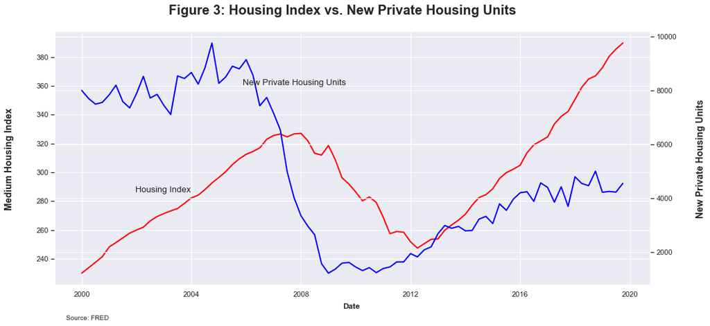

```python
sns.set_theme(style="darkgrid")
fig, ax = plt.subplots(figsize = (16, 7))
ax.plot(house.monthYear, house['Housing Index'], linewidth = 2, c = 'red')

fig.text(0.06, 0.5, "Medium Housing Index", va = 'center', weight = 'bold', fontsize = 14, rotation = 'vertical')
fig.text(0.50, 0.06, 'Date', va = 'center', weight = 'bold', fontsize = 12)
fig.suptitle("Figure 3: Housing Index vs. New Private Housing Units", weight = 'bold', fontsize = 20, y = 0.96)
fig.text(0.14, 0.02, 'Source: FRED', fontsize = 10, weight = 'normal')

fig.text(0.23, 0.40, "Housing Index",  weight = 'normal', fontsize = 13)
fig.text(0.37, 0.72, "New Private Housing Units",  weight = 'normal', fontsize = 13)

ax2= ax.twinx()
ax2.plot(house.monthYear, house['New Private Housing Units'], linewidth = 2, c = 'blue')
fig.text(0.96, 0.5, "New Private Housing Units", va = 'center', weight = 'bold', fontsize = 14, rotation = 'vertical')
```

**Housing Index vs. All employee, Social Assistance & education, health**

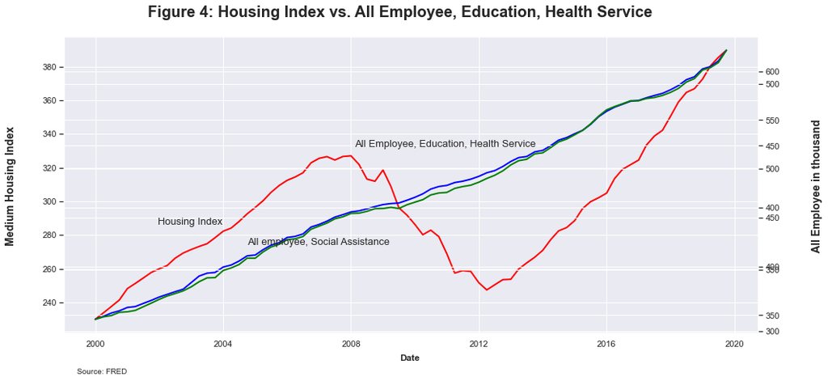

```python
sns.set_theme(style="darkgrid")
fig, ax = plt.subplots(figsize = (16, 7))
ax.plot(house.monthYear, house['Housing Index'], linewidth = 2, c = 'red')

fig.text(0.06, 0.5, "Medium Housing Index", va = 'center', weight = 'bold', fontsize = 14, rotation = 'vertical')
fig.text(0.50, 0.06, 'Date', va = 'center', weight = 'bold', fontsize = 12)
fig.suptitle("Figure 4: Housing Index vs. All Employee, Education, Health Service", weight = 'bold', fontsize = 20, y = 0.96)
fig.text(0.14, 0.02, 'Source: FRED', fontsize = 10, weight = 'normal')

fig.text(0.23, 0.40, "Housing Index",  weight = 'normal', fontsize = 13)
fig.text(0.45, 0.60, "All Employee, Education, Health Service",  weight = 'normal', fontsize = 13)
fig.text(0.33, 0.35, "All employee, Social Assistance",  weight = 'normal', fontsize = 13)

ax2= ax.twinx()
ax2.plot(house.monthYear, house['All Employee, Education, Health Service'], linewidth = 2, c = 'blue')
fig.text(0.96, 0.5, "All Employee in thousand", va = 'center', weight = 'bold', fontsize = 14, rotation = 'vertical')

ax3= ax.twinx()
ax3.plot(house.monthYear, house['All employee, Social Assistance '], linewidth = 2, c = 'green')
```

# Data Visualization pt.2

In this part, we will continue our data analysis by visualizing the trend of change in difference between variables

**Housing Index vs. Median Household Income **(Difference)****

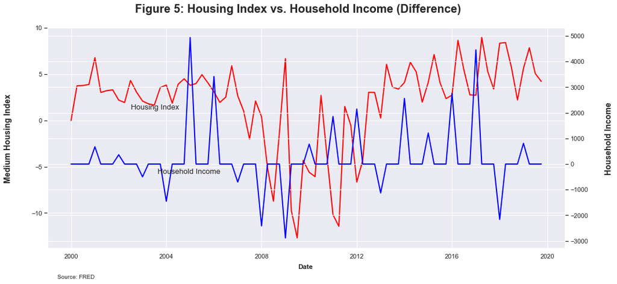

```python
sns.set_theme(style="darkgrid")
fig, ax = plt.subplots(figsize = (16, 7))
ax.plot(houseDiff.monthYear, houseDiff['Housing Index'], linewidth = 2, c = 'red')

fig.text(0.06, 0.5, "Medium Housing Index", va = 'center', weight = 'bold', fontsize = 14, rotation = 'vertical')
fig.text(0.50, 0.06, 'Date', va = 'center', weight = 'bold', fontsize = 12)
fig.suptitle("Figure 5: Housing Index vs. Household Income (Difference)", weight = 'bold', fontsize = 20, y = 0.96)
fig.text(0.14, 0.02, 'Source: FRED', fontsize = 10, weight = 'normal')

fig.text(0.25, 0.60, "Housing Index",  weight = 'normal', fontsize = 13)
fig.text(0.29, 0.38, "Household Income",  weight = 'normal', fontsize = 13)

ax2= ax.twinx()
ax2.plot(houseDiff.monthYear, houseDiff['Median Household Income'], linewidth = 2, c = 'blue')
fig.text(0.96, 0.5, "Household Income", va = 'center', weight = 'bold', fontsize = 14, rotation = 'vertical')
```

$\Delta$household income seems to have an inverse relationship with housing index. As housing index increase, $\Delta$household income decreases.

**Housing Index vs. New Private Housing Units (Difference)**

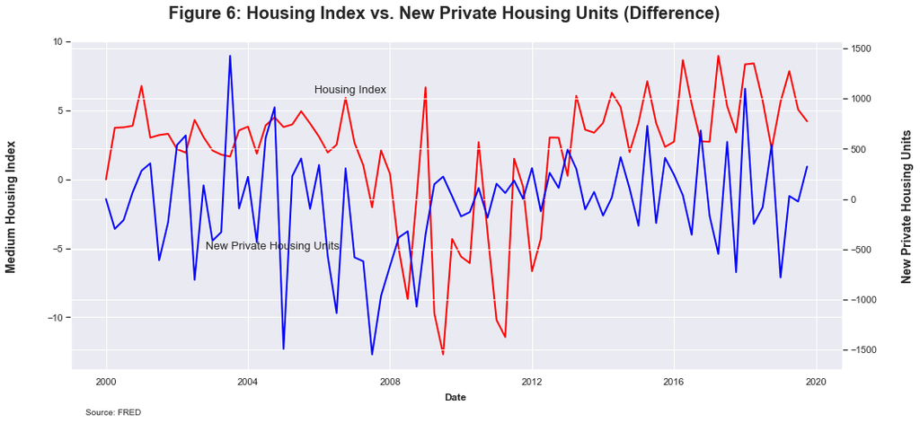

```python
sns.set_theme(style="darkgrid")
fig, ax = plt.subplots(figsize = (16, 7))
ax.plot(houseDiff.monthYear, houseDiff['Housing Index'], linewidth = 2, c = 'red')

fig.text(0.06, 0.5, "Medium Housing Index", va = 'center', weight = 'bold', fontsize = 14, rotation = 'vertical')
fig.text(0.50, 0.06, 'Date', va = 'center', weight = 'bold', fontsize = 12)
fig.suptitle("Figure 6: Housing Index vs. New Private Housing Units (Difference)", weight = 'bold', fontsize = 20, y = 0.96)
fig.text(0.14, 0.02, 'Source: FRED', fontsize = 10, weight = 'normal')

fig.text(0.37, 0.76, "Housing Index",  weight = 'normal', fontsize = 13)
fig.text(0.26, 0.40, "New Private Housing Units",  weight = 'normal', fontsize = 13)

ax2= ax.twinx()
ax2.plot(houseDiff.monthYear, houseDiff['New Private Housing Units'], linewidth = 2, c = 'blue')
fig.text(0.96, 0.5, "New Private Housing Units", va = 'center', weight = 'bold', fontsize = 14, rotation = 'vertical')
```

There is no clear relationship between housing index and $\Delta$new private housing units indicated in the graph above. Thus, it would be interesting to investigate more via regression.

**Housing Index vs. Unemployment(Difference)**

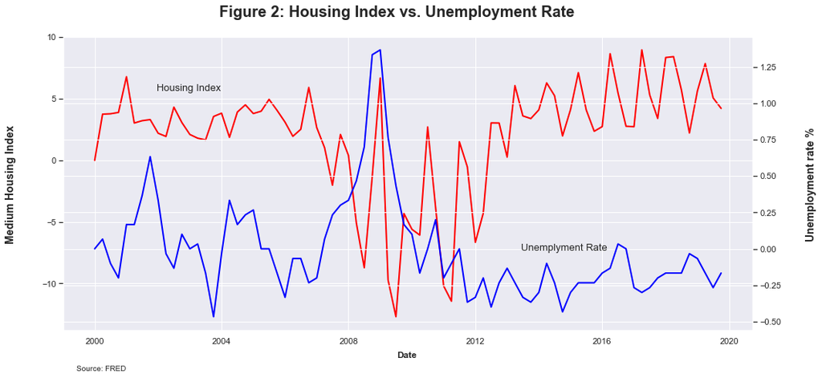

```python
sns.set_theme(style="darkgrid")
fig, ax = plt.subplots(figsize = (16, 7))
ax.plot(houseDiff.monthYear, houseDiff['Housing Index'], linewidth = 2, c = 'red')

fig.text(0.06, 0.5, "Medium Housing Index", va = 'center', weight = 'bold', fontsize = 14, rotation = 'vertical')
fig.text(0.50, 0.06, 'Date', va = 'center', weight = 'bold', fontsize = 12)
fig.suptitle("Figure 2: Housing Index vs. Unemployment Rate", weight = 'bold', fontsize = 20, y = 0.96)
fig.text(0.14, 0.02, 'Source: FRED', fontsize = 10, weight = 'normal')

fig.text(0.23, 0.74, "Housing Index",  weight = 'normal', fontsize = 13)
fig.text(0.64, 0.33, "Unemplyment Rate",  weight = 'normal', fontsize = 13)

ax2= ax.twinx()
ax2.plot(houseDiff.monthYear, houseDiff['Unemployment rate'], linewidth = 2, c = 'blue')
fig.text(0.96, 0.5, "Unemployment rate %", va = 'center', weight = 'bold', fontsize = 14, rotation = 'vertical')
```

From the graph above, an inverse relationship is indicated. in the anomaly around 2008, housing index decreases as $\Delta$unemployment increases; in the years where housing index does not fluctuate much, $\Delta$unemployment is relative stable.

# Regression Analysis

```python
# make a copy of the house to rename of the dataframe to conduct regression analysis
houseDiffReg = houseDiff.copy()
houseReg = house.copy()
houseReg.columns = ['DATE', 'houseIndex', 'houseUnits', 'unemployRate', "socialAssistance", "healthService", "houseIncome", "monthYear"]

houseDiffReg.columns = ['DATE', 'houseIndex', 'houseUnits', 'unemployRate', "socialAssistance", "healthService", "houseIncome", "monthYear"]

houseReg.head()
```

|  | DATE | houseIndex | houseUnits | unemployRate | socialAssistance | healthService | houseIncome | monthYear |
| --- | --- | --- | --- | --- | --- | --- | --- | --- |
| 0 | 2000-01-01 | 229.98 | 7993.215447 | 3.633333 | 309.833333 | 345.900000 | 41901 | 2000-01-01 |
| 1 | 2000-04-01 | 233.73 | 7696.030050 | 3.700000 | 311.733333 | 348.766667 | 41901 | 2000-04-01 |
| 2 | 2000-07-01 | 237.51 | 7486.817740 | 3.600000 | 312.800000 | 352.266667 | 41901 | 2000-07-01 |
| 3 | 2000-10-01 | 241.40 | 7551.963652 | 3.400000 | 315.433333 | 354.533333 | 41901 | 2000-10-01 |
| 4 | 2001-01-01 | 248.19 | 7833.710288 | 3.566667 | 315.866667 | 358.000000 | 42576 | 2001-01-01 |

```python
modelHouse = smf.ols('houseIndex ~ houseUnits + unemployRate + socialAssistance + healthService + houseIncome', data=houseReg).fit()
modelHouseDiff = smf.ols('houseIndex ~ houseUnits + unemployRate + socialAssistance + healthService + houseIncome', data=houseDiffReg).fit()
```

```python
st=Stargazer([modelHouse, modelHouseDiff])
st.title("Regression on HouseIndex")
st.custom_columns(['modelHouse', 'modelHouseDiff'], [1, 1])
st.covariate_order(['houseIncome', 'houseUnits', 'unemployRate', 'socialAssistance', 'healthService', 'Intercept'])
from IPython.core.display import HTML
HTML(st.render_html())
```

Regression on HouseIndex

|  | *Dependent variable:houseIndex* |  |
| --- | --- | --- |
|  | modelHouse | modelHouseDiff |
|  | (1) | (2) |
| houseIncome | 0.001 | -0.001 |
|  | (0.002) | (0.000) |
| houseUnits | 0.000 | -0.000 |
|  | (0.002) | (0.001) |
| unemployRate | -7.904*** | -3.793** |
|  | (2.889) | (1.629) |
| socialAssistance | -3.913 | -0.462 |
|  | (2.516) | (0.735) |
| healthService | 3.398* | 1.004 |
|  | (2.003) | (0.674) |
| Intercept | 276.216** | -0.144 |
|  | (108.796) | (1.055) |
| Observations | 80 | 80 |
| R<sup>2</sup> | 0.631 | 0.171 |
| Adjusted R<sup>2</sup> | 0.606 | 0.115 |
| Residual Std. Error | 23.568 (df=74) | 4.354 (df=74) |
| F Statistic | 25.342*** (df=5; 74) | 3.052** (df=5; 74) |
| Note: | *p<0.1; **p<0.05; ***p<0.01 |  |

# Results

From the regression analysis we can get the following model:

$$ Medium house index = 0.001houseIncome - 7.904unemployRate - 3.913socialAssistance + 3.398healthService + 276.216$$

We can also dissect the model to examine the individual factor effect on the medium house index when controllling for other factors:

- **houseIncome**: an unit increase in houseIncome leads to 0.001 increase in the Medium house index
- **unemployRate**: an one percertage point increase in unEmployment rate leads to 7.904 decrease in the medium house index
- **socialAssistance**: a thousand increase in number of people in social assistance decreases the medium house index by 3.913
- **healthService**: a thousand increase in the number of people in health service increases the medium house index by 3.398
- **intercept**: when all factors are zero, the medium house index is 276.216

The model also provides an $$R^2 = 0.631$$ which means that about 63.1% of the variations in the response variable can be explained by the independent variables.

Nevertheless, this doesn't mean that each factor is significant in this regression model. From the table we see that only `unemployRate`, `healthService`, and `Intercept` pass the least significance threshold (p < 0.1), and only `unemployRate` pass the highest significance threshold (p < 0.01). Therefore, the regression model indicates that while number of people in health service and unemployment rate are influencial for the medium house index, unemployment rate is the most statistically significant factor in determining the variation in the medium house index.

# Discussion

In this project we exmaine possible factors influencing the change in the medium housing index in Georgia (GA), United States. From the regression model we discovered that only unemployment rate in GA is the most statistically significant factors in the regression model. This is reasonable as we normally use the unemployment rate as an indicator of the purchasing power of the consumers. Hence, it's rational that as unemployment rate goes up, the medium housing index decreases since sellers would want to lower the price to sell more houses.

Future studies should expand factors of interest such as population of the state, distance relative to central cities, etc. The analysis can also be conducted in state-level. For example, compare the medium housing price between states of low GDP and states of high GDP. In addition, we can also conduct cross-sectional analysis study between countries to examine larger factors such as GDP, export, etc., and how do these factors influence the outcome of housing index.

**Packages used in this document**

`numpy`  
`pandas`  
`matplotlib.pyplot`  
`seaborn`  
`statsmodels.api`  
`scipy.stats`  
`stargazer.stargazer`

```python
!jupyter nbconvert --to html finalProject.ipynb
```

```
[NbConvertApp] Converting notebook finalProject.ipynb to html
[NbConvertApp] Writing 1623648 bytes to finalProject.html
```